# STAT 413/613 HW 3: Lists and Iteration

Yunting Chiu

2020-09-15

# Instructions

1. Clone this homework repo to your homework directory as a new repo.
2. Rename the starter file under the analysis directory as `hw_01_yourname.Rmd` and use it for your solutions.
3. Modify the “author” field in the YAML header.
4. Stage and Commit R Markdown and HTML files (no PDF files).
5. **Push both .Rmd and HTML files to GitHub**.
- Make sure you have knitted to HTML prior to staging, committing, and pushing your final submission.
6. **Commit each time you answer a part of question, e.g. 1.1**
7. **Push to GitHub after each major question**
8. When complete, submit a response in Canvas
- Only include necessary code to answer the questions.
- Most of the functions you use should be from the tidyverse. Too much base R will result in point deductions.
- Use Pull requests and or email to ask me any questions. If you email, please ensure your most recent code is pushed to GitHub.
- Learning Outcomes:
  - Manipulate vectors in base-R syntax.
  - Apply iterations with for loops.

**Libraries**

```r
library(tidyverse)
library(stats)
```

# 1 Working with Lists

Because of their generality, lists (or list-like objects) are often the output of many statistical procedures in R. The file `fpout.RDS` in the data folder contains sample output from using fitPoly, a statistical method to quantify properties of locations on the [genome](https://www.ncbi.nlm.nih.gov/pmc/articles/PMC5915555/).

1. Use `readRDS()` and a relative path to read this data into R.

```r
fpout <- readRDS(file = "../data/fpout.RDS")
```

2. Use appropriate functions to obtain the length of the list and then the vector of the names from the list.

```r
length(fpout)
```

```
## [1] 7
```

```r
names(fpout)
```

```
## [1] "log"          "modeldata"    "allmodeldata" "scores"       "diploscores"
## [6] "time"         "prop_miss"
```

3. The `diploscores` element does not provide any information. Remove it from the list.

```r
fpout_01 <- fpout[-c(5)]

# check again
length(fpout_01)
```

```
## [1] 6
```

```r
names(fpout_01)
```

```
## [1] "log"          "modeldata"    "allmodeldata" "scores"       "time"
## [6] "prop_miss"
```

```r
# second method
#fpout$diploscores <- NULL

# third method
#[[5]] <- NULL
```

4. The `scores` element contains the output most users would want. The variables in `scores` called `P0`, `P1`, `P2`, `P3`, `P4`, `P5`, and `P6` contain “posterior probabilities” for each individual for values `0`, `1`, `2`, `3`, `4`, `5`, and `6` (respectively).
- A quantity useful in Bayesian analysis is called the “posterior mean,” which in this case is calculated as follows:
  - posterior_mean = `(P0 * 0) + (P1 * 1) + (P2 * 2) + (P3 * 3) + (P4 * 4) + (P5 * 5) + (P6 * 6)`.
- Calculate the posterior mean for each individual and add this as a new variable in the `scores` data frame.

```r
fpout_01$scores %>%
  mutate(Posterior_Mean = (P0 * 0) + (P1 * 1) + (P2 * 2) + (P3 * 3) + (P4 * 4) + (P5 * 5) + (P6 * 6)) -> scores_01

head(scores_01)
```

```
##   marker MarkerName SampleName     ratio P0            P1           P2
## 1      1        SNP          2 0.9450980  0  0.000000e+00 0.000000e+00
## 2      1        SNP          3 0.9186047  0  1.513089e-70 1.630727e-32
## 3      1        SNP          4 0.9976387  0 4.965532e-143 6.960499e-85
## 4      1        SNP          5 1.0000000  0 3.237313e-161 5.236498e-99
## 5      1        SNP          6 0.9202756  0  2.644688e-71 5.145367e-33
## 6      1        SNP          7 0.9037620  0  4.181303e-64 2.965385e-28
##              P3           P4           P5            P6 maxgeno      maxP geno
## 1 5.487698e-278 1.792528e-95 1.000000e+00 1.765903e-145       5 1.0000000    5
## 2  1.688654e-15 8.489692e-05 9.999151e-01  2.727826e-18       5 0.9999151    5
## 3  2.023616e-54 1.173498e-31 8.163299e-14  1.000000e+00       6 1.0000000    6
## 4  7.915965e-66 1.252725e-40 5.265544e-20  1.000000e+00       6 1.0000000    6
## 5  7.908401e-16 5.665944e-05 9.999433e-01  6.710451e-18       5 0.9999433    5
## 6  1.067884e-12 2.639557e-03 9.973604e-01  1.287973e-21       5 0.9973604    5
##   Posterior_Mean
## 1       5.000000
## 2       4.999915
## 3       6.000000
## 4       6.000000
## 5       4.999943
## 6       4.997360
```

5. Use a `map*()` function to identify the names of the variables in the `scores` data frame that are *not* of type double.

```r
map(scores_01, typeof)
```

```
## $marker
## [1] "integer"
##
## $MarkerName
## [1] "character"
##
## $SampleName
## [1] "integer"
##
## $ratio
## [1] "double"
##
## $P0
## [1] "double"
##
## $P1
## [1] "double"
##
## $P2
## [1] "double"
##
## $P3
## [1] "double"
##
## $P4
## [1] "double"
##
## $P5
## [1] "double"
##
## $P6
## [1] "double"
##
## $maxgeno
## [1] "double"
##
## $maxP
## [1] "double"
##
## $geno
## [1] "double"
##
## $Posterior_Mean
## [1] "double"
```

```r
# $marker, $MarkerName, and $SampleName, are not dbl type
```

- Create a new element called `col_means` in the list that contains just the column means of all the *double* variables in the `scores` data frame.

```r
scores_01 %>%
 select(ratio:Posterior_Mean) -> scores_02
col_means <- list(col_means = map_dbl(scores_02, mean, na.rm = TRUE))

#  Create a new list called `col_means`
print(col_means)
```

```
## $col_means
##          ratio             P0             P1             P2             P3
##   9.110837e-01  1.141826e-236   5.571926e-24   3.159587e-06   1.528993e-02
##             P4             P5             P6        maxgeno           maxP
##   2.535163e-01   5.074307e-01   2.237600e-01   4.951049e+00   9.780702e-01
##           geno Posterior_Mean
##   5.095652e+00   4.939654e+00
```

```r
# adding to the existing list to "fpout_02"
append(fpout_01, col_means) -> fpout_02
# test whether is successful or not
length(fpout_02)
```

```
## [1] 7
```

6. Demonstrate three different ways to extract the `col_means` element from the list. The extracted element should *not* be a list.

```r
# first way
fpout_02[[7]]
```

```
##          ratio             P0             P1             P2             P3
##   9.110837e-01  1.141826e-236   5.571926e-24   3.159587e-06   1.528993e-02
##             P4             P5             P6        maxgeno           maxP
##   2.535163e-01   5.074307e-01   2.237600e-01   4.951049e+00   9.780702e-01
##           geno Posterior_Mean
##   5.095652e+00   4.939654e+00
```

```r
# second way
fpout_02$col_means
```

```
##          ratio             P0             P1             P2             P3
##   9.110837e-01  1.141826e-236   5.571926e-24   3.159587e-06   1.528993e-02
##             P4             P5             P6        maxgeno           maxP
##   2.535163e-01   5.074307e-01   2.237600e-01   4.951049e+00   9.780702e-01
##           geno Posterior_Mean
##   5.095652e+00   4.939654e+00
```

```r
# third method
fpout_02[["col_means"]]
```

```
##          ratio             P0             P1             P2             P3
##   9.110837e-01  1.141826e-236   5.571926e-24   3.159587e-06   1.528993e-02
##             P4             P5             P6        maxgeno           maxP
##   2.535163e-01   5.074307e-01   2.237600e-01   4.951049e+00   9.780702e-01
##           geno Posterior_Mean
##   5.095652e+00   4.939654e+00
```

```r
# we can always check with str()
```

- Show two ways to extract the third element of `col_means`

```r
# first way
fpout_02$col_means[c(3)]
```

```
##           P1
## 5.571926e-24
```

```r
#second way
fpout_02$col_means[c("P1")]
```

```
##           P1
## 5.571926e-24
```

```r
#third way (optional)
fpout_02$col_means[c(-1, -2, -4, -5, -6, -7, -8, -9, -10, -11, -12)]
```

```
##           P1
## 5.571926e-24
```

# 2 For Loops

- Proper Function structure

```r
calcn <- function(x, n){
  nums <- vector(mode = "integer", length = n) # set nums type
  for(i in seq_along(nums)){
    if (i <= 3){
      nums[i] <- x[i] # 1, 2, 3 can not be calculated so keep it
    }
    else {
      nums[i] <- nums[i-1] + (abs(nums[i-3] - nums[i-2]))/4 # start working formula with 4
    }

    }
    return(nums[n]) # return Xn in formula
}

calcn(x = c(2, 4, 3), n = 3)
```

```
## [1] 3
```

```r
calcn(x = c(2, 4, 3), n = 4)
```

```
## [1] 3.5
```

```r
calcn(x = c(2, 4, 3), n = 5)
```

```
## [1] 3.75
```

```r
calcn(x = c(2, 4, 3), n = 6)
```

```
## [1] 3.875
```

```r
calcn(x = c(2, 4, 3), n = 7)
```

```
## [1] 3.9375
```

- Error checks

```r
calcn <- function(x, n){
  if (length(x) == 3){
    if(n > 0 & is.integer(n)){
  nums <- vector(mode = "integer", length = n)
  for(i in seq_along(nums)){
    if(i <= 3){
      nums[i] <- x[i]
    }else{
      nums[i] <- nums[i-1] + (abs(nums[i-3] - nums[i-2]))/4
    }

    }
  return(nums[n])
    }else{
      stop("n must > 0 and n must be an integer")

    } # error check n
  }else{
    stop("the length of x should be 3")

    } # error check x
} # created calcn function


calcn(x = c(2, 4, 3), n = 7L) # correct x and n type
```

```
## [1] 3.9375
```

```r
calcn(x = c(2, 4), n = 7) # length of x < 3
```

```
## Error in calcn(x = c(2, 4), n = 7): the length of x should be 3
```

```r
calcn(x = c(2, 4, 3, 5), n = 6) # length of x > 3
```

```
## Error in calcn(x = c(2, 4, 3, 5), n = 6): the length of x should be 3
```

```r
calcn(x = c(2, 4, 3), n = 0) # n <= 0
```

```
## Error in calcn(x = c(2, 4, 3), n = 0): n must > 0 and n must be an integer
```

```r
calcn(x = c(2, 4, 3), n = 5.53) # n is a float(dbl)
```

```
## Error in calcn(x = c(2, 4, 3), n = 5.53): n must > 0 and n must be an integer
```

- Evaluate your function at the following inputs:
  - calcn(c(11,1,130), 1000L)
  - calcn(c(11,1,130), 1L)
  - calcn(c(7, 3, 20), 8L)

```r
calcn(c(11,1,130), 1000L)
```

```
## [1] 176.3333
```

```r
calcn(c(11,1,130), 1L)
```

```
## [1] 11
```

```r
calcn(c(7, 3, 20), 8L)
```

```
## [1] 26.625
```

# 3 Question: Lists, For-loops, and `map_*()`

Lists are often used to save simulation output. You can then extract individual elements from the lists using for-loops.

Consider the $t$-test, used to test whether or not the mean of some observations is 0. We would use the following code to simulate data from a [Normal (0,1) distribution](https://en.wikipedia.org/wiki/Normal_distribution), and then use a $t$-test to test if the true mean is 0:

```r
x <- rnorm(n = 10, mean = 0, sd = 1)
tout <- t.test(x)
tout
```

```
##
##  One Sample t-test
##
## data:  x
## t = -1.8481, df = 9, p-value = 0.09764
## alternative hypothesis: true mean is not equal to 0
## 95 percent confidence interval:
##  -1.3254173  0.1335062
## sample estimates:
##  mean of x
## -0.5959556
```

1. The output of `t.test()` is a list-like object. Use one function to show how many elements are in the list along with their names and types.

```r
# only one function to show all
str(tout)
```

```
## List of 10
##  $ statistic  : Named num -1.85
##   ..- attr(*, "names")= chr "t"
##  $ parameter  : Named num 9
##   ..- attr(*, "names")= chr "df"
##  $ p.value    : num 0.0976
##  $ conf.int   : num [1:2] -1.325 0.134
##   ..- attr(*, "conf.level")= num 0.95
##  $ estimate   : Named num -0.596
##   ..- attr(*, "names")= chr "mean of x"
##  $ null.value : Named num 0
##   ..- attr(*, "names")= chr "mean"
##  $ stderr     : num 0.322
##  $ alternative: chr "two.sided"
##  $ method     : chr "One Sample t-test"
##  $ data.name  : chr "x"
##  - attr(*, "class")= chr "htest"
```

```r
# how many elements
length(tout)
```

```
## [1] 10
```

```r
# names
names(tout)
```

```
##  [1] "statistic"   "parameter"   "p.value"     "conf.int"    "estimate"
##  [6] "null.value"  "stderr"      "alternative" "method"      "data.name"
```

```r
# types
typeof(tout)
```

```
## [1] "list"
```

```r
is_double(tout)
```

```
## [1] FALSE
```

2. Write a for-loop to perform the following three operations on iteration `i`:
   1. Draw 10 random observations from a normal distribution with mean 0 and standard deviation 2.
   2. Run a $t$-test on these 10 observations.
   3. Save the output of the $t$-test as the `i`th element in a list called `tlist`.
- Set the seed to 1 and run for 1000 iterations.

```r
set.seed(1)
tlist <- list()
x <- list()
for(i in 1:1000) {
  x[[i]] <- rnorm(10, mean = 0, sd = 2) # draw 10 random observations
  tlist[[i]] <- t.test(x[[i]]) # t-test the x for each time then save to the tlist
}

# randomly test some tlists
tlist[[1]]
```

```
##
##  One Sample t-test
##
## data:  x[[i]]
## t = 0.53557, df = 9, p-value = 0.6052
## alternative hypothesis: true mean is not equal to 0
## 95 percent confidence interval:
##  -0.8523895  1.3812007
## sample estimates:
## mean of x
## 0.2644056
```

```r
tlist[[20]]
```

```
##
##  One Sample t-test
##
## data:  x[[i]]
## t = -0.52263, df = 9, p-value = 0.6139
## alternative hypothesis: true mean is not equal to 0
## 95 percent confidence interval:
##  -1.5732947  0.9827645
## sample estimates:
##  mean of x
## -0.2952651
```

```r
tlist[[300]]
```

```
##
##  One Sample t-test
##
## data:  x[[i]]
## t = -0.582, df = 9, p-value = 0.5749
## alternative hypothesis: true mean is not equal to 0
## 95 percent confidence interval:
##  -2.725734  1.610202
## sample estimates:
## mean of x
## -0.557766
```

3. Use the appropriate map function to extract the sample mean from each test (from 2) and pipe to an appropriate plot to show the sampling distribution of the sample mean.
- Hint: Make sure the data going into ggplot is a data frame (tibble)
- QQ plots are for testing against a known distribution or comparing two distributions to see if they are similar.
- Histogram is the more appropriate plot here.

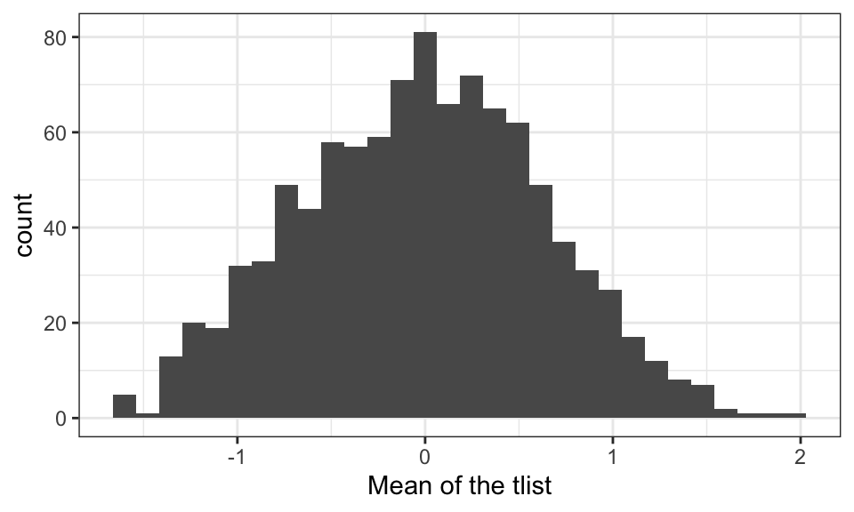

```r
tlist %>%
map_dbl(~.$estimate) -> tlist_mean # extract the mean of each tlist
as_tibble(tlist_mean) -> tlist_mean01 # make sure the data save as data frame type

# plot to histogram
tlist_mean01 %>%
 ggplot(aes(x = value))+
  geom_histogram()+
  theme_bw()+
  xlab("Mean of the tlist")
```

```r
#tlist_mean01 %>%
 #ggplot(aes(sample = value))+
  #geom_qq()+
  #theme_bw()
```

4. The $p$-value is an important quantity in statistics. Use a for-loop to extract the $p$-values from each test in part 2 and combine these $p$-values into a single vector called `pvec_f`. Show the first 6 values.

```r
pvec_f <- vector() # set pvec_f is a vector type

# start for loop
for(i in 1:1000) {
  pvec_f[[i]] <- tlist[[i]]$p.value # recall tlist$p.value to extract it
}

head(pvec_f)
```

```
## [1] 0.6052327 0.4806056 0.6686761 0.6480420 0.4945143 0.6653161
```

5. Use the appropriate map function to extract the $p$-values from each test in part 2 and combine these $p$-values into a single vector called `pvec_m`. Show the first 6 values.

```r
map_dbl(tlist, ~.$p.value) -> pvec_m

head(pvec_m)
```

```
## [1] 0.6052327 0.4806056 0.6686761 0.6480420 0.4945143 0.6653161
```

6. *Extra Credit* $p$-values have a nice property where, if the the null hypothesis is true (i.e. the mean of the observations is actually 0), then the $p$-values follow the uniform distribution.
- Use the data from `pvec_m` to create a [QQ-plot](https://en.wikipedia.org/wiki/Q–Q_plot) and then interpret the plot with regard to whether the $p$-values exhibit a uniform distribution.
- Ensure your plot has appropriate labels for the axes and a title.
- Include an abline that is dashed and colored red.

**Interpretation:** If $p$-values is uniformly distributed, the null hypothesis should be true. In this plot, we can see these two lines are almost sticking together, which means this statistical evidence indicates tlist’s $p$-values is uniformly distributed.

```r
pvec_m %>%
  as_tibble(pvec_m) -> dfpvec_m # make sure the data save as data frame type
```

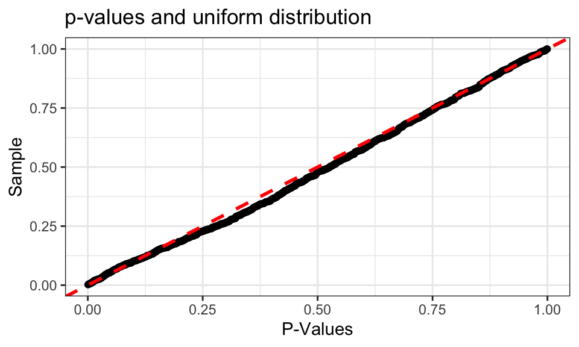

```r
  ggplot(data = dfpvec_m)+
  geom_qq(distribution = stats::qunif, mapping = aes(sample = pvec_m))+
  geom_abline(color = "red", linetype = "dashed", size = 1)+ # "qunif" gives the quantile function
  theme_bw()+
  labs(x = "P-Values", y = "Sample")+
  ggtitle("p-values and uniform distribution")
```